# Lecture 4 Moving Average Models

## Review: Autoregressive Model

Deterministic trend model:
$$Y_t = X_t'\beta + Z_t$$
Autoregressive model for deviations from trend:
$$E(Z_t \ | \ {\mathscr{Z}}_{t-1} ) = \phi_1 Z_{t-1}$$

Prediction depends on the previous value of $Z_{t-1}$.

## Review: Autoregressive Model

Deterministic trend model:
$$Y_t = X_t'\beta + Z_t$$
Autoregressive model for deviations from trend:
$${\color{lime}{E(Z_t \ | \ {\mathscr{Z}}_{t-1} )}}
= {\color{orange}{\phi_1 Z_{t-1}}}$$
$${\color{magenta}{Z_t \, -\: }} {\color{lime}{E(Z_t \ | \ {\mathscr{Z}}_{t-1} )}} =
{\color{magenta}{Z_t \,-\: }} {\color{orange}{\phi_1 Z_{t-1}}}$$

## Review: Autoregressive Model

Deterministic trend model:
$$Y_t = X_t'\beta + Z_t$$
Autoregressive model for deviations from trend:
$${\color{white}{E(Z_t \ | \ {\mathscr{Z}}_{t-1} )}}
= {\color{white}{\phi_1 Z_{t-1}}}$$

$${\color{red}{Z_t \, -\: }} {\color{red}{E(Z_t \ | \ {\mathscr{Z}}_{t-1} )}} =
{\color{white}{Z_t \,-\: }} {\color{white}{\phi_1 Z_{t-1}}}$$

$$\qquad\qquad\qquad {\color{red}{U_t }} \quad =
{\color{white}{Z_t \,-\: }} {\color{white}{\phi_1 Z_{t-1}}}$$

$$\color{red}{\text{One-step-ahead}}$$

$$\color{red}{\text{prediction error }^\rightarrow}$$

## Review: Autoregressive Model

Deterministic trend model:
$$Y_t = X_t'\beta + Z_t$$
Autoregressive model for deviations from trend:
$${\color{white}{E(Z_t \ | \ {\mathscr{Z}}_{t-1} )}}
= {\color{white}{\phi_1 Z_{t-1}}}$$

$$\qquad\qquad\qquad {\color{red}{U_t }} \quad =
{\color{white}{Z_t \,-\: }} {\color{white}{\phi_1 Z_{t-1}}}$$

$$\qquad\qquad\qquad Z_t \quad =
\phi_1 Z_{t-1} + {\, \color{red}{U_t}}$$

## Review: Autoregressive Model

Deterministic trend model:
$$Y_t = X_t'\beta + Z_t$$
Autoregressive model for deviations from trend:
$$Z_t =
\phi_1 Z_{t-1} + U_t$$

## Moving average model

Deterministic trend model:
$$Y_t = X_t'\beta + Z_t$$

Moving average model for deviations from trend:
$$E(Z_t \ | \ {\mathscr{Z}}_{t-1} ) = \theta_1 \
(Z_{t-1}- E(Z_{t-1} \ | \ {\mathscr{Z}}_{t-2} ))$$

## Moving average model

Deterministic trend model:
$$Y_t = X_t'\beta + Z_t$$

Moving average model for deviations from trend:
$$E(Z_t \ | \ {\mathscr{Z}}_{t-1} ) = \theta_1 \
{\color{cyan}{(Z_{t-1}- E(Z_{t-1} \ | \ {\mathscr{Z}}_{t-2} ))}}$$

Prediction depends on the previous *prediction error*.

## Moving average model

Deterministic trend model:
$$Y_t = X_t'\beta + Z_t$$

Moving average model for deviations from trend:
$$E(Z_t \ | \ {\mathscr{Z}}_{t-1} ) = \theta_1 \
{\color{cyan}{(Z_{t-1}- E(Z_{t-1} \ | \ {\mathscr{Z}}_{t-2} ))}}$$
$$\phantom{E(Z_t \ | \ {\mathscr{Z}}_{t-1} ) } = \theta_1 \:
{\color{cyan}{U_{t-1}}} \qquad\qquad\qquad\qquad\,$$

## Moving average model

Deterministic trend model:
$$Y_t = X_t'\beta + Z_t$$

Moving average model for deviations from trend:
$$E(Z_t \ | \ {\mathscr{Z}}_{t-1} ) = \theta_1 \
{\color{cyan}{U_{t-1}}} \qquad\qquad\qquad\qquad\:$$

## Moving average model

Deterministic trend model:
$$Y_t = X_t'\beta + Z_t$$

Moving average model for deviations from trend:
$${\color{orange}{E(Z_t \ | \ {\mathscr{Z}}_{t-1} )}}
= \theta_1 \
{\color{cyan}{U_{t-1}}} \qquad\qquad\qquad\qquad\:$$

$${\color{magenta}{Z_t \, - \: }}
{\color{orange}{E(Z_t \ | \ {\mathscr{Z}}_{t-1} ) }}
= {\color{magenta}{Z_t \, - \: }} \theta_1 \
{\color{cyan}{U_{t-1}}} \qquad\qquad$$

## Moving average model

Deterministic trend model:
$$Y_t = X_t'\beta + Z_t$$

Moving average model for deviations from trend:
$${\color{white}{E(Z_t \ | \ {\mathscr{Z}}_{t-1} )}}
= \theta_1 \
{\color{cyan}{U_{t-1}}} \qquad\qquad\qquad\qquad\:$$

$${\color{cyan}{Z_t \, - \: }}
{\color{cyan}{E(Z_t \ | \ {\mathscr{Z}}_{t-1} ) }}
= {\color{white}{Z_t \, - \: }} \theta_1 \
{\color{cyan}{U_{t-1}}} \qquad\qquad$$

$$\quad {\color{cyan}{U_t}} \quad \:
= {\color{white}{Z_t}}
- \theta_1 \: {\color{cyan}{U_{t-1}}}$$

## Moving average model

Deterministic trend model:
$$Y_t = X_t'\beta + Z_t$$

Moving average model for deviations from trend:

$$\quad {\color{cyan}{U_t}} \quad \:
= {\color{white}{Z_t}}
- \theta_1 \: {\color{cyan}{U_{t-1}}}$$

$$Z_t \: = \: U_t \: + \: \theta_1 U_{t-1}$$

## Moving average model

Deterministic trend model:
$$Y_t = X_t'\beta + Z_t$$

Moving average model for deviations from trend:
$$Z_t \: = \: U_t \: + \: \theta_1 U_{t-1}$$

## AR(*p*) model

Deterministic trend model:
$$Y_t = X_t'\beta + Z_t$$

AR(*p*) model for deviations from trend:
$$Z_t \: = \: \phi_1 Z_{t-1} + \ldots + \phi_p Z_{t-p} + U_t$$

## MA(*q*) model

Deterministic trend model:
$$Y_t = X_t'\beta + Z_t$$

MA(*q*) model for deviations from trend:
$$Z_t \: = \: U_t + \theta_1 U_{t-1} + \ldots + \theta_q U_{t-q}$$

## ARMA(*p*,*q*) model

Deterministic trend model:
$$Y_t = X_t'\beta + Z_t$$

ARMA(*p*,*q*) model for deviations from trend:
$$\begin{align}
Z_t \: &= \: \phi_1 Z_{t-1} + \ldots + \phi_p Z_{t-p} \\
& \qquad + \, U_t + \theta_1 U_{t-1} + \ldots + \theta_q U_{t-q}
\end{align}$$

## ARMA(*p*,*q*) model selection

Same *practical* approach as AR(*p*) selection:

- check residual autocorrelation tests
- choose model with smallest AICc

Also *in theory* we can look at autocorrelations of the time series.

## First difference of interest rates

(3 month Bank Accepted Bills)

```r
dt <- read.csv("BAB3mth.csv")
Y <- ts(dt$BAB3,
        start=c(2010,1),
        end=c(2025,6),
        frequency=12)
Y <- window(Y, end=c(2020,12))
DY <- diff(Y)
```

## First difference of interest rates

(3 month Bank Accepted Bills)

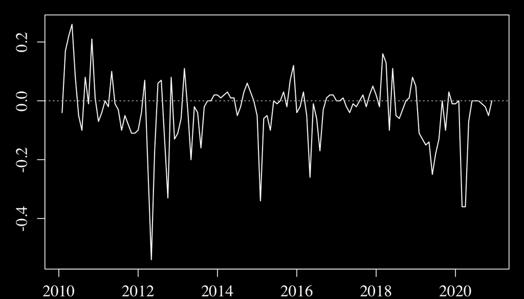

## First difference of interest rates

```r
acf(DY)
```

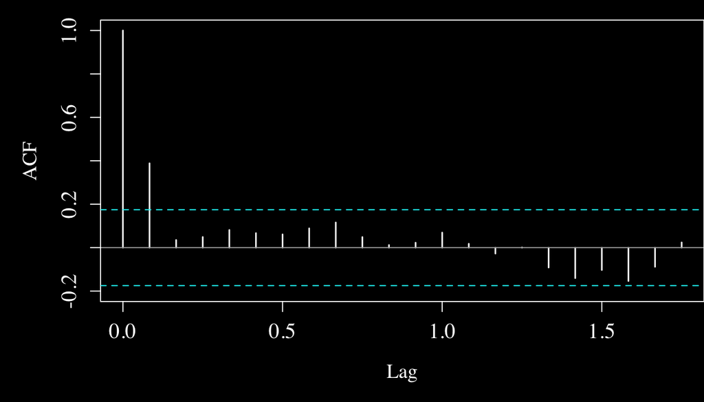

## Theoretical autocorrelation function

```r
acf_AR1 <- ARMAacf(ar=0.4, lag.max=18)
```

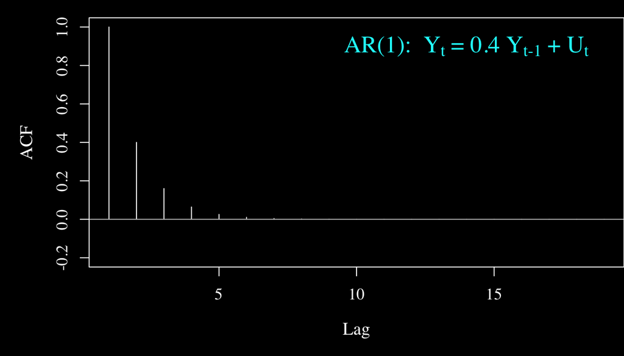

## Theoretical autocorrelation function

```r
acf_MA1 <- ARMAacf(ma=0.5, lag.max=18)
```

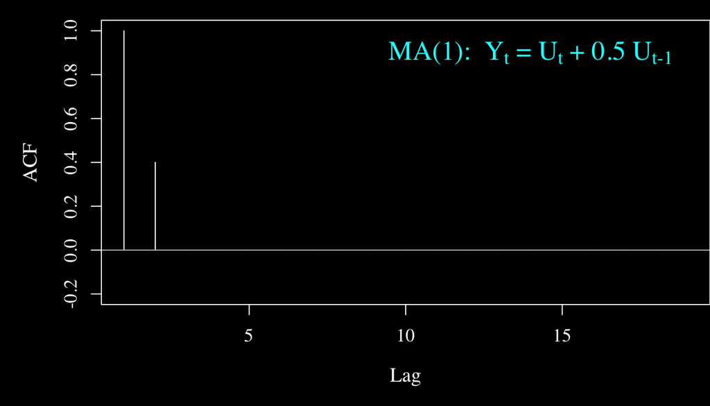

## Theoretical autocorrelation function

```r
acf_MA1 <- ARMAacf(ma=0.5, lag.max=18)
```

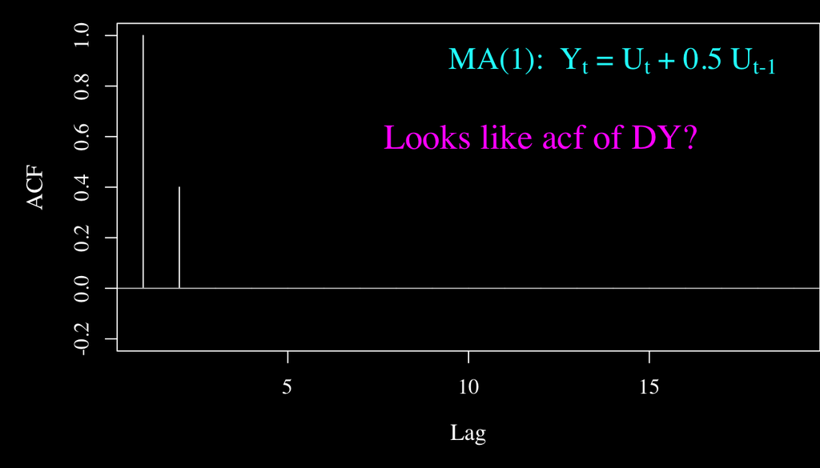

## Some other theoretical acf’s

```r
acf_AR2 <- ARMAacf(ar=c(0.4,0.2), lag.max=18)
```

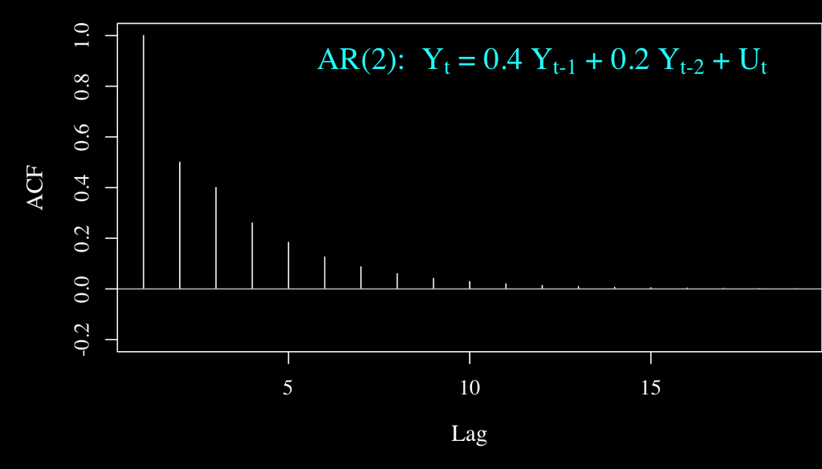

## Some other theoretical acf’s

```r
acf_MA2 <- ARMAacf(ma=c(0.5,0.5), lag.max=18)
```

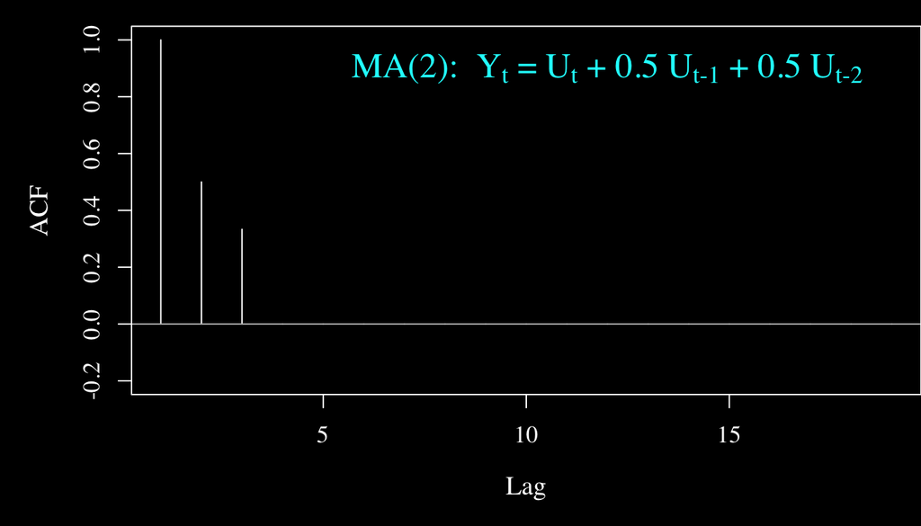

## Some other theoretical acf’s

```r
acf_ARMA11 <- ARMAacf(ar=0.4, ma=0.5, lag.max=18)
```

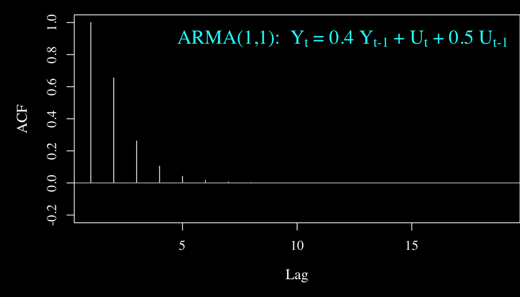

## Partial autocorrelation function

Recall autocorrelation at lag *k*:

correlation between ${\color{lime}{Y_t}}$ and ${\color{lime}{Y_{t-k}}}$ for any $k=1,2,3,\ldots$.

*Partial* autocorrelation at lag *k*:

correlation between ${\color{lime}{Y_t}}$ and ${\color{lime}{Y_{t-k}}}$ *after controlling for intermediate lags* ${\color{orange}{Y_{t-1},\ldots,Y_{t-k+1}}}$.

## Partial autocorrelation function

*Partial* autocorrelation at lag *k*:

correlation between ${\color{lime}{Y_t}}$ and ${\color{lime}{Y_{t-k}}}$ *after controlling for intermediate lags* ${\color{orange}{Y_{t-1},\ldots,Y_{t-k+1}}}$.

i.e. correlation between ${\color{lime}{Y_{t|k}^*}}$ and ${\color{lime}{Y_{t-k|k}^*}}$ where

$Y_{t|k}^*$ and $Y_{t-k|k}^*$ are residuals from regressions of ${\color{orange}{Y_t}}$ and ${\color{orange}{Y_{t-k}}}$ on ${\color{orange}{Y_{t-1},\ldots,Y_{t-k+1}}}$.

## Theoretical partial autocorrelation function

```r
pacf_AR1 <- ARMAacf(ar=0.4,  pacf=TRUE,  lag.max=18)
```

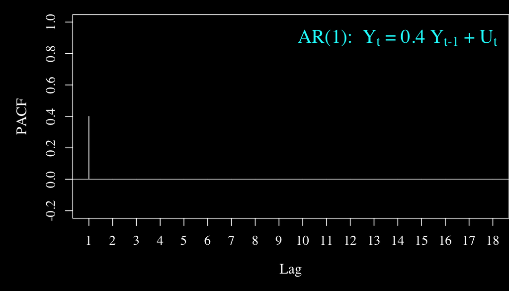

## Theoretical partial autocorrelation function

```r
pacf_MA1 <- ARMAacf(ma=0.5,  pacf=TRUE,  lag.max=18)
```

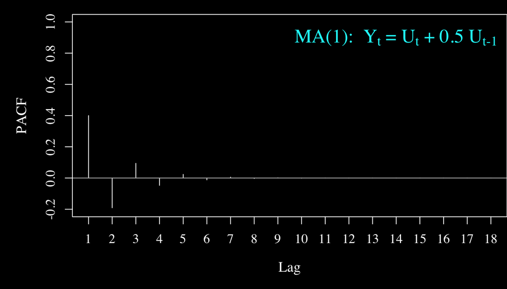

## Theoretical partial autocorrelation function

```r
pacf_ARMA11 <- ARMAacf(ar=0.2, ma=0.4, pacf=TRUE, lag.max=18)
```

[figure not shown]

## Theoretical ACF and PACF patterns

As lag increases:

$$\begin{array}{l|ll}
& \text{ACF} & \text{PACF} \\
\hline
\text{AR}(p) & \text{declines}
& \text{zero after } p \text{ lags} \\
\text{MA}(q)
& \text{zero after } q \text{ lags}
& \text{declines} \\
\text{ARMA}(p,q)
& \text{declines}
& \text{declines} \\
\hline
\end{array}$$

## Example: MA(1)

$$Z_t = U_t + \theta_1 U_{t-1}, \quad
U_t=Z_t-E(Z_t|{\mathscr{Z}}_{t-1})$$

- Recall $\text{cov}(U_t,U_{t-k})=0$ for every $k=1,2,\ldots$.
- *Assume* $\text{var}(U_t) = \sigma^2$ for every $t$.

## Example: MA(1)

$${\color{lime}{Z_t = U_t + \theta_1 U_{t-1}}}, \quad
U_t=Z_t-E(Z_t|{\mathscr{Z}}_{t-1})$$

- Recall $\text{cov}(U_t,U_{t-k})=0$ for every $k=1,2,\ldots$.
- *Assume* $\text{var}(U_t) = \sigma^2$ for every $t$.

$\text{cov}({\color{lime}{Z_t}}, {\color{lime}{Z_{t-1}}}) = \text{cov}({\color{lime}{U_t+\theta_1 U_{t-1}}}, \: {\color{lime}{U_{t-1}+\theta_1 U_{t-2}}})$

## Example: MA(1)

$$Z_t = U_t + \theta_1 U_{t-1}, \quad
U_t=Z_t-E(Z_t|{\mathscr{Z}}_{t-1})$$

- Recall $\text{cov}(U_t,U_{t-k})=0$ for every $k=1,2,\ldots$.
- *Assume* $\text{var}(U_t) = \sigma^2$ for every $t$.

$\text{cov}(Z_t, Z_{t-1}) = \text{cov}({\color{cyan}{U_t}} + \theta_1 {\color{lime}{U_{t-1}}}, \: {\color{magenta}{U_{t-1}}} +\theta_1 {\color{orange}{U_{t-2}}})$ $\phantom{\text{cov}(Z_t, Z_{t-1})} = \text{cov}({\color{cyan}{U_t}},\, {\color{magenta}{U_{t-1}}}) + \theta_1 \text{cov}({\color{lime}{U_{t-1}}},\, {\color{magenta}{U_{t-1}}})$ $\phantom{\text{cov}(Z_t, Z_{t-1})} \qquad + \theta_1 \text{cov}({\color{cyan}{U_t}},\, {\color{orange}{U_{t-2}}})$ $\phantom{\text{cov}(Z_t, Z_{t-1})} \qquad + \theta_1^2 \text{cov}({\color{lime}{U_{t-1}}},\, {\color{orange}{U_{t-2}}})$

## Example: MA(1)

$$Z_t = U_t + \theta_1 U_{t-1}, \quad
U_t=Z_t-E(Z_t|{\mathscr{Z}}_{t-1})$$

- Recall $\text{cov}(U_t,U_{t-k})=0$ for every $k=1,2,\ldots$.
- *Assume* $\text{var}(U_t) = \sigma^2$ for every $t$.

$\text{cov}(Z_t, Z_{t-1}) = \text{cov}(U_t,\, U_{t-1}) + \theta_1 \text{cov}(U_{t-1},\, U_{t-1})$ $\phantom{\text{cov}(Z_t, Z_{t-1})} \qquad + \theta_1 \text{cov}(U_t,\, U_{t-2})$ $\phantom{\text{cov}(Z_t, Z_{t-1})} \qquad + \theta_1^2 \text{cov}(U_{t-1},\, U_{t-2})$

## Example: MA(1)

$$Z_t = U_t + \theta_1 U_{t-1}, \quad
U_t=Z_t-E(Z_t|{\mathscr{Z}}_{t-1})$$

- Recall ${\color{cyan}{\text{cov}(U_t,U_{t-k})=0}}$ for every $k=1,2,\ldots$.
- *Assume* ${\color{magenta}{\text{var}(U_t) = \sigma^2}}$ for every $t$.

$\text{cov}(Z_t, Z_{t-1}) = {\color{cyan}{\text{cov}(U_t,\, U_{t-1})}} + \theta_1 {\color{magenta}{\text{cov}(U_{t-1},\, U_{t-1})}}$ $\phantom{\text{cov}(Z_t, Z_{t-1})} \qquad + \theta_1 {\color{cyan}{\text{cov}(U_t,\, U_{t-2})}}$ $\phantom{\text{cov}(Z_t, Z_{t-1})} \qquad + \theta_1^2 {\color{cyan}{\text{cov}(U_{t-1},\, U_{t-2})}}$

## Example: MA(1)

$$Z_t = U_t + \theta_1 U_{t-1}, \quad
U_t=Z_t-E(Z_t|{\mathscr{Z}}_{t-1})$$

- Recall ${\color{cyan}{\text{cov}(U_t,U_{t-k})=0}}$ for every $k=1,2,\ldots$.
- *Assume* ${\color{magenta}{\text{var}(U_t) = \sigma^2}}$ for every $t$.

$\text{cov}(Z_t, Z_{t-1}) = \qquad {\color{cyan}{0}} \qquad\quad + \theta_1 \quad {\color{magenta}{\sigma^2}}$ $\phantom{\text{cov}(Z_t, Z_{t-1})} \qquad + \theta_1 \quad {\color{cyan}{0}}$ $\phantom{\text{cov}(Z_t, Z_{t-1})} \qquad + \theta_1^2 \quad {\color{cyan}{0}}$

## Example: MA(1)

$$Z_t = U_t + \theta_1 U_{t-1}, \quad
U_t=Z_t-E(Z_t|{\mathscr{Z}}_{t-1})$$

- Recall $\text{cov}(U_t,U_{t-k})=0$ for every $k=1,2,\ldots$.
- *Assume* $\text{var}(U_t) = \sigma^2$ for every $t$.

$\text{cov}(Z_t, Z_{t-1}) = \, \theta_1 \, \sigma^2$

## Example: MA(1)

$$Z_t = U_t + \theta_1 U_{t-1}, \quad
U_t=Z_t-E(Z_t|{\mathscr{Z}}_{t-1})$$

- Recall ${\color{cyan}{\text{cov}(U_t,U_{t-k})=0}}$ for every $k=1,2,\ldots$.
- *Assume* $\text{var}(U_t) = \sigma^2$ for every $t$.

$\text{cov}(Z_t, Z_{t-{\color{red}{2}}}) = {\color{cyan}{\text{cov}(U_t,\, U_{t-2})}} + \theta_1 {\color{cyan}{\text{cov}( U_{t-1},\, U_{t-2})}}$ $\phantom{\text{cov}(Z_t, Z_{t-1})} \qquad + \theta_1 {\color{cyan}{\text{cov}(U_t,\, U_{t-3})}}$ $\phantom{\text{cov}(Z_t, Z_{t-1})} \qquad + \theta_1^2 {\color{cyan}{\text{cov}( U_{t-1},\, U_{t-3})}}$

$\phantom{\text{cov}(Z_t, Z_{t-1})} = {\color{cyan}{0}}$

## Example: MA(1)

$$Z_t = U_t + \theta_1 U_{t-1}, \quad
U_t=Z_t-E(Z_t|{\mathscr{Z}}_{t-1})$$

- Recall ${\color{cyan}{\text{cov}(U_t,U_{t-k})=0}}$ for every $k=1,2,\ldots$.
- *Assume* $\text{var}(U_t) = \sigma^2$ for every $t$.

For any $k>1:$  
$\quad\text{cov}(Z_t, Z_{t-{\color{red}{k}}}) = {\color{cyan}{\text{cov}(U_t,\, U_{t-k})}} + \theta_1 {\color{cyan}{\text{cov}( U_{t-1},\, U_{t-k})}}$ $\quad\phantom{\text{cov}(Z_t, Z_{t-1})} \qquad + \theta_1 {\color{cyan}{\text{cov}(U_t,\, U_{t-k-1})}}$  
$\quad\phantom{\text{cov}(Z_t, Z_{t-1})} \qquad + \theta_1^2 {\color{cyan}{\text{cov}( U_{t-1},\, U_{t-k-1})}}$  
$\quad\phantom{\text{cov}(Z_t, Z_{t-1})} = {\color{cyan}{0}}$

## Example: AR(1)

$$Z_t = \phi_1 Z_{t-1} + U_t, \quad
U_t=Z_t-E(Z_t|{\mathscr{Z}}_{t-1})$$

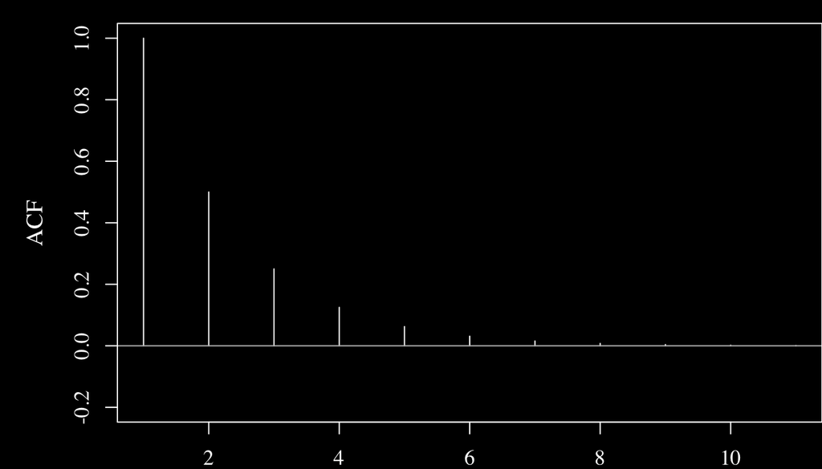

## First difference of interest rates

```r
acf(DY, type="partial")
```

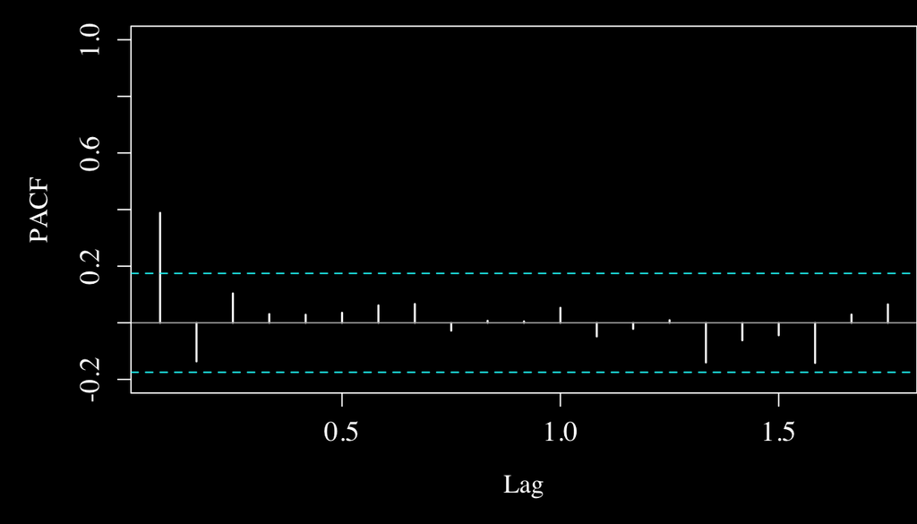

## First difference of interest rates

```r
acf(DY)
```

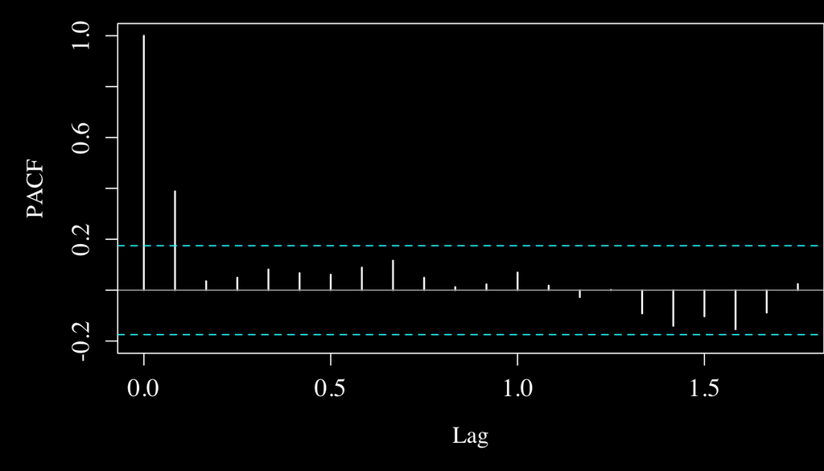

## First difference of interest rates

```r
acf(DY)
```

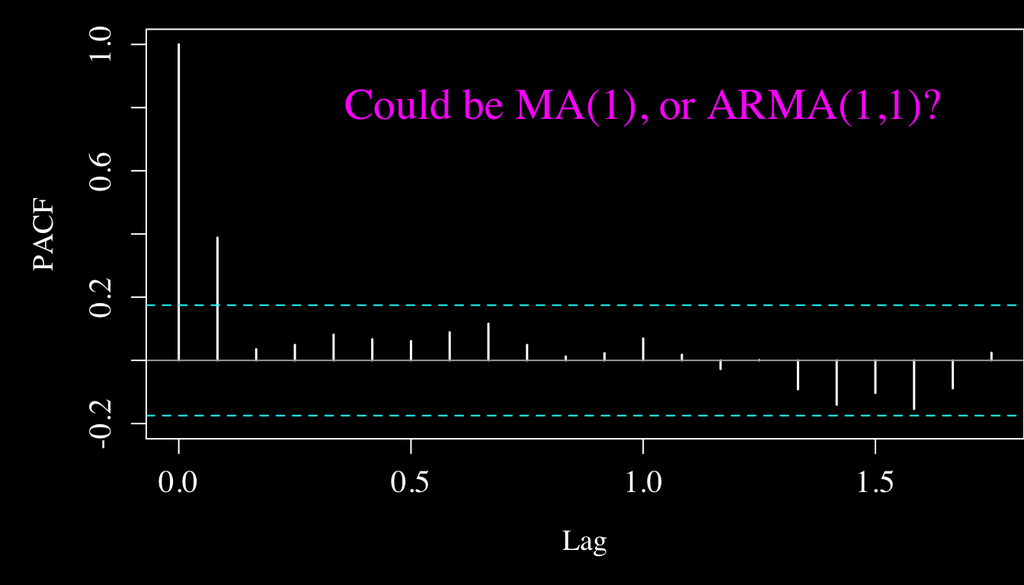

## Model estimation: AR(1)

```r
AR1 <- Arima(DY, order=c(1,0,0))
print(AR1)
```

```
Series: DY
ARIMA(1,0,0) with non-zero mean

Coefficients:
         ar1     mean
      0.3858  -0.0318
s.e.  0.0801   0.0145

sigma^2 = 0.01062:  log likelihood = 112.71
AIC=-219.43   AICc=-219.24   BIC=-210.8
```

## Model estimation: MA(1)

```r
MA1 <- Arima(DY, order=c(0,0,1))
print(MA1)
```

```
Series: DY
ARIMA(0,0,1) with non-zero mean

Coefficients:
         ma1     mean
      0.4434  -0.0320
s.e.  0.0762   0.0127

sigma^2 = 0.01035:  log likelihood = 114.39
AIC=-222.77   AICc=-222.58   BIC=-214.15
```

## Model estimation: ARMA(1,1)

```r
ARMA11 <- Arima(DY, order=c(1,0,1))
print(ARMA11)
```

```
Series: DY
ARIMA(1,0,1) with non-zero mean

Coefficients:
         ar1     ma1    mean
      0.0558  0.3989  -0.032
s.e.  0.1915  0.1758   0.013

sigma^2 = 0.01043:  log likelihood = 114.43
AIC=-220.86   AICc=-220.54   BIC=-209.36
```

## Residual autocorrelation testing

```r
LBp_AR1 <- checkresiduals(AR1)
```

```
    Ljung-Box test

data:  Residuals from ARIMA(1,0,0) with non-zero mean
Q* = 19, df = 23, p-value = 0.7012

Model df: 1.   Total lags used: 24
```

${\color{lime}{\Large\checkmark}}$

## Residual autocorrelation testing

```r
LBp_MA1 <- checkresiduals(MA1)
```

```
    Ljung-Box test

data:  Residuals from ARIMA(0,0,1) with non-zero mean
Q* = 16.201, df = 23, p-value = 0.8465

Model df: 1.   Total lags used: 24
```

${\color{lime}{\Large\checkmark}}$

## Residual autocorrelation testing

```r
LBp_ARMA11 <- checkresiduals(ARMA11)
```

```
    Ljung-Box test

data:  Residuals from ARIMA(1,0,1) with non-zero mean
Q* = 15.748, df = 22, p-value = 0.8282

Model df: 2.   Total lags used: 24
```

${\color{lime}{\Large\checkmark}}$

## Model selection: AICc

```
          AICc
AR1    -219.24
MA1    -222.58
ARMA11 -220.54
```

${\color{lime}{\Large\checkmark}}$

- All three models pass autocorrelation tests.
- The AICc prefers the MA(1) model.

## Summary

One step ahead prediction error:  
$\qquad\qquad\qquad\quad U_t = Z_t - E(Z_t | {\mathscr{Z}}_{t-1})$

$$\text{MA}(q): \qquad\quad\:\: Z_t = U_t + \theta_1 U_{t-1} + \ldots + \theta_q U_{t-q}
\qquad\qquad$$

$$\begin{align}
\text{ARMA}(p,q): \quad
Z_t =& \: \phi_1 Z_{t-1} + \ldots + \phi_p Z_{t-p} \\
&+ U_t + \theta_1 U_{t-1} + \ldots + \theta_q U_{t-q}
\qquad\qquad\qquad\qquad
\end{align}$$

Select $p,q$ using AICc and autocorrelation tests.

## Summary

As lag increases:

$$\begin{array}{l|ll}
& \text{ACF} & \text{PACF} \\
\hline
\text{AR}(p) & \text{declines}
& \text{zero after } p \text{ lags} \\
\text{MA}(q)
& \text{zero after } q \text{ lags}
& \text{declines} \\
\text{ARMA}(p,q)
& \text{declines}
& \text{declines} \\
\hline
\end{array}$$